# import libraray

-clarity

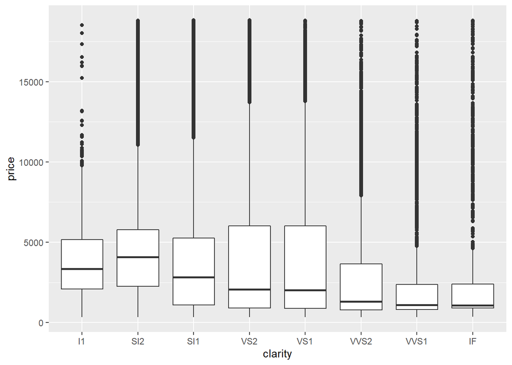

```r
ggplot(data = diamonds) + geom_boxplot(aes(x =clarity, y = price))
```

약한 음의 상관관계가 있습니다.

-color

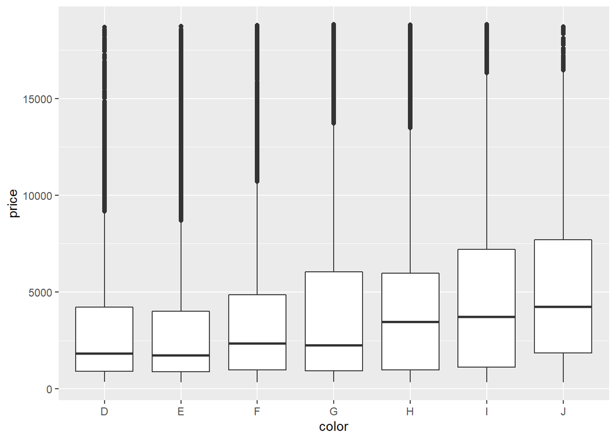

```r
ggplot(data = diamonds) + geom_boxplot(aes(x = color, y = price))
```

약한 음의 상관관계가 있습니다. color은 D가 best입니다. price에 가장 영향을 많이 주는 변수를 carat입니다.

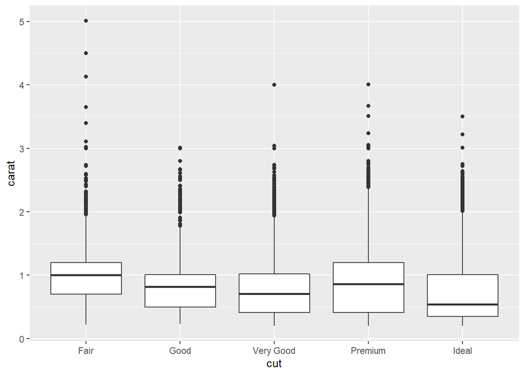

```r
ggplot(data = diamonds) + geom_boxplot(aes(x = cut, y = carat))
```

캐럿과 컷사이에는 음의 상관관계가 있습니다. 크기가 큰 다이아몬드라면 컷이 이상적이지 않아도 팔리지만 크기가 작다면 컷에 더 신경써야하기 때문이라고 생각합니다.  
# Textbook 7.5.2.1

## Problem 2

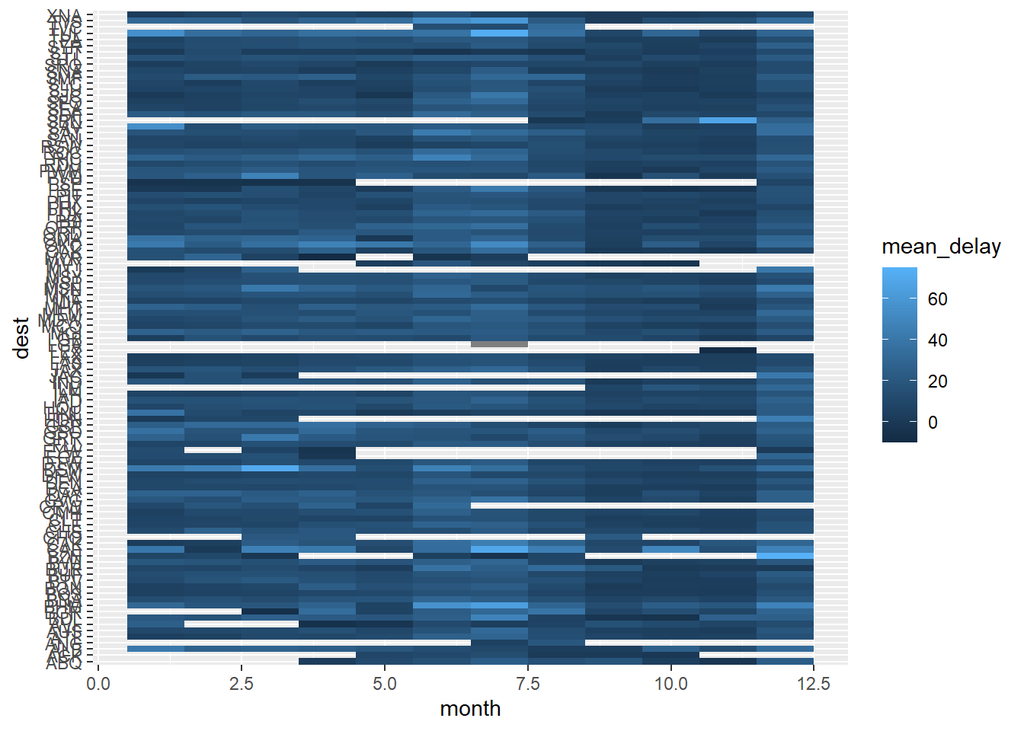

```r
flights %>% group_by(dest, month) %>% summarise(mean_delay = mean(dep_delay, na.rm= TRUE)) %>% ggplot() + geom_tile(mapping = aes(x = month, y = dest, fill =  mean_delay))
```

그래프를 읽기 어렵게 만드는 요소들은 다음과 같습니다. 1. x축은 month를 나타내지만, 위 그래프에서는 소수로 표현되어 있습니다. 2. 데이터에 결측치가 포함되어 있어 그래프를 해석하기 어렵게 만듭니다.

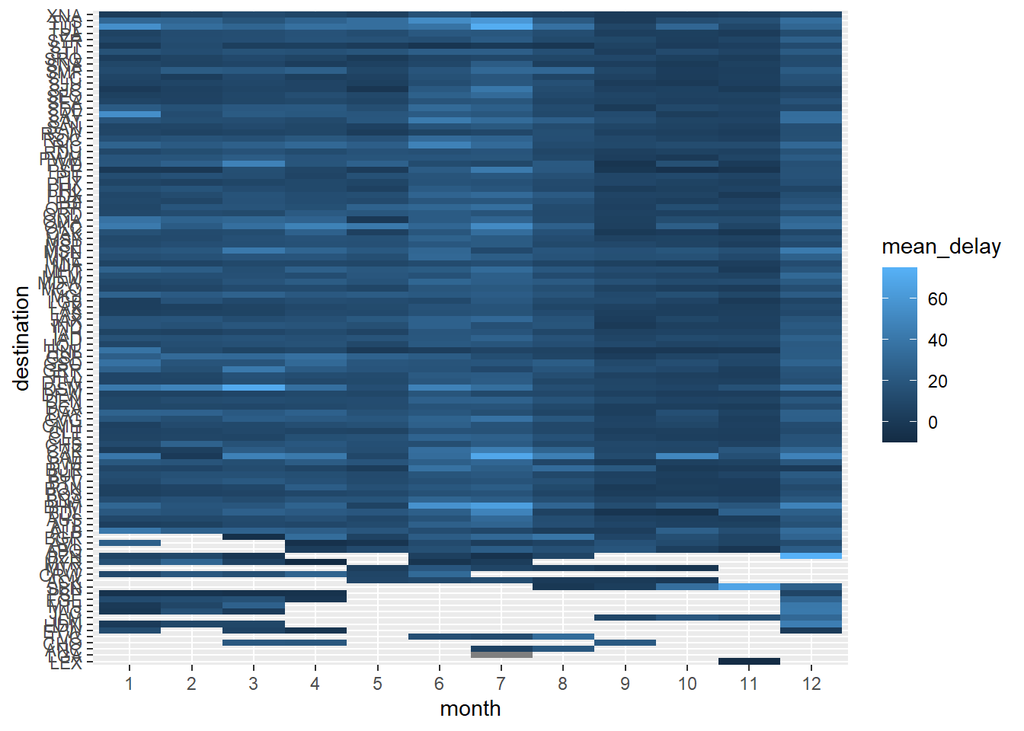

```r
flights %>% group_by(dest, month) %>% summarise(mean_delay = mean(dep_delay, na.rm= TRUE)) %>%  ungroup() %>%
  group_by(dest) %>% mutate(count_month = n())%>%
  ggplot() + geom_tile(mapping = aes(x = factor(month), y = reorder(dest, count_month), fill =  mean_delay)) + labs(x = "month", y = "destination")
```

1번의 문제를 해결하기 위해 `factor(month)`으로 벡터를 팩터와 하였습니다. 2번의 문제를 해결하기 위해 목적지마다 항공편의 개수를 세어 많은 순서대로 정렬하여 나타나도록 하였습니다.

# Textbook 7.5.3.1

##Problem 4

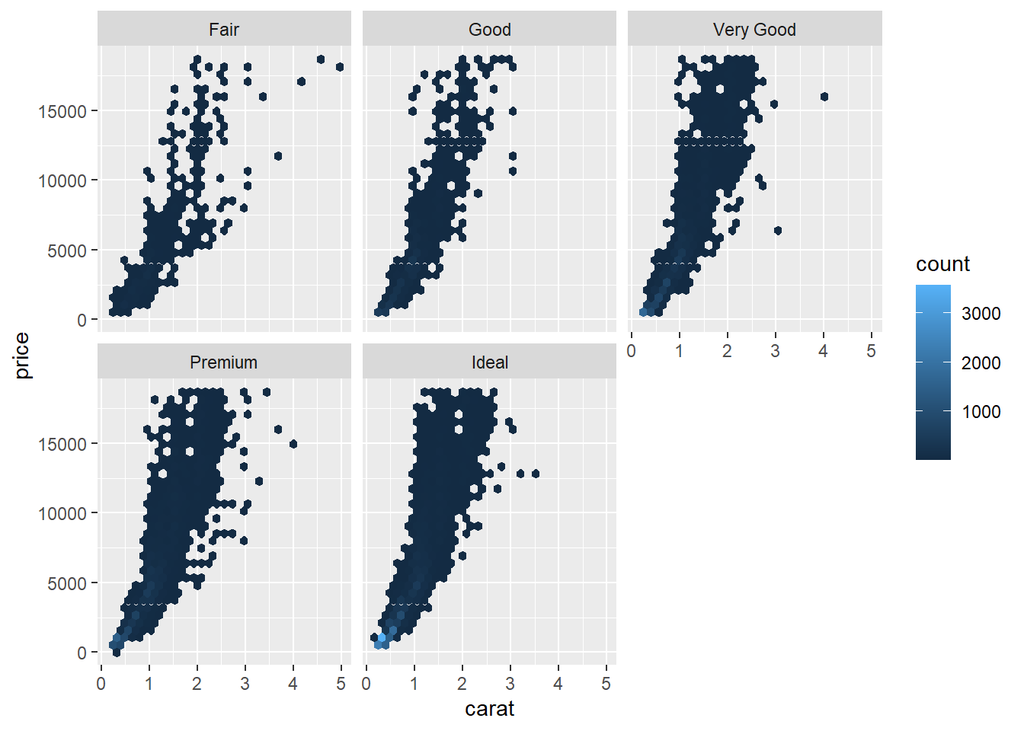

```r
ggplot(data = diamonds) + geom_hex(mapping = aes(x = carat, y = price)) + facet_wrap(~cut)
```

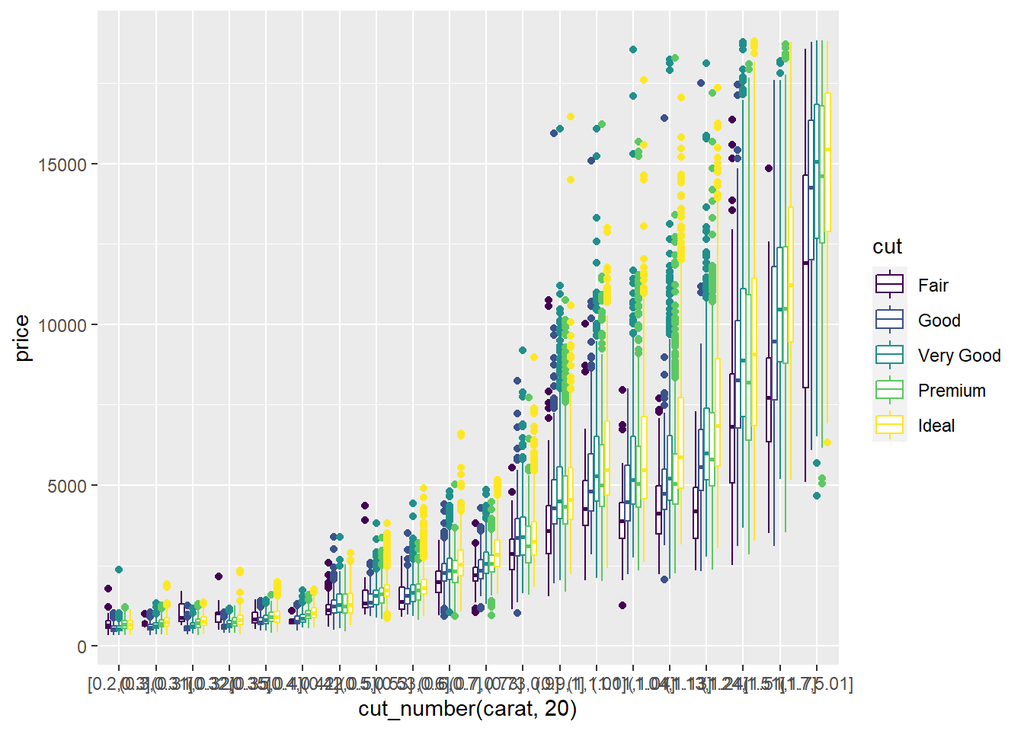

```r
ggplot(data = diamonds) + geom_boxplot(mapping = aes(x = cut_number(carat, 20), y = price, color = cut))
```

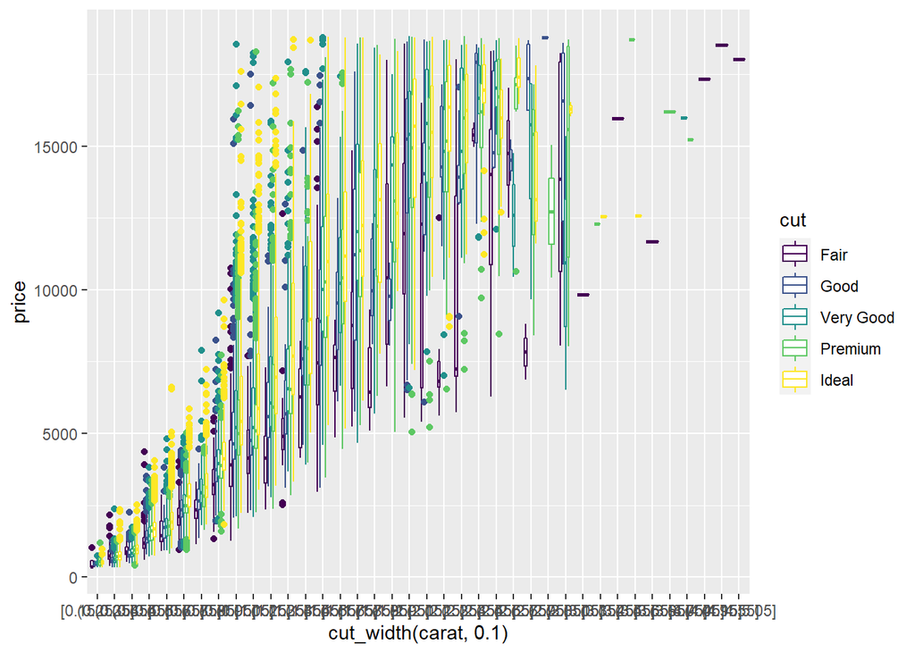

```r
ggplot(data = diamonds) + geom_boxplot(mapping = aes(x = cut_width(carat, 0.1), y = price, color = cut))
```

# Textbook 10.5

## Problem 2

```r
df <- data.frame(abc = 1, xyz = "a")
```

```r
df2 <- tibble(abc = 1, xyz = "a")
df$x
```

```
## [1] "a"
```

```r
df2$x
```

data frame에서 $ 연산자는 뒤따르는 값으로 시작하는 열을 불러올 수 있었지만 tibble에서는 그렇지 못합니다. 그래서  
`df2$xyz`로 xyz column에 해당하는 값을 불러올 수 있습니다.

```r
df2$xyz
```

```
## [1] "a"
```

```r
df[, "xyz"]
```

```
## [1] "a"
```

```r
df2[, "xyz"]
```

```
## # A tibble: 1 × 1
##   xyz
##   <chr>
## 1 a
```

data frame에서는 []을 사용하여 하나의 column을 불러오면, 벡터로 출력됩니다. 하지만 tibble에서는 tibble의 한 column을 출력합니다.

```r
df[, c("abc", "xyz")]
```

```
##   abc xyz
## 1   1   a
```

```r
df2[, c("abc", "xyz")]
```

```
## # A tibble: 1 × 2
##     abc xyz
##   <dbl> <chr>
## 1     1 a
```

data frame에서 []을 사용하여 2개 이상의 column을 불러오면, data frame으로 출력됩니다.

## Problem 4

```r
annoying <- tibble(
  `1` = 1:10,
  `2` = `1` * 2 + rnorm(length(`1`))
)
```

```r
annoying$'1'
```

```
##  [1]  1  2  3  4  5  6  7  8  9 10
```

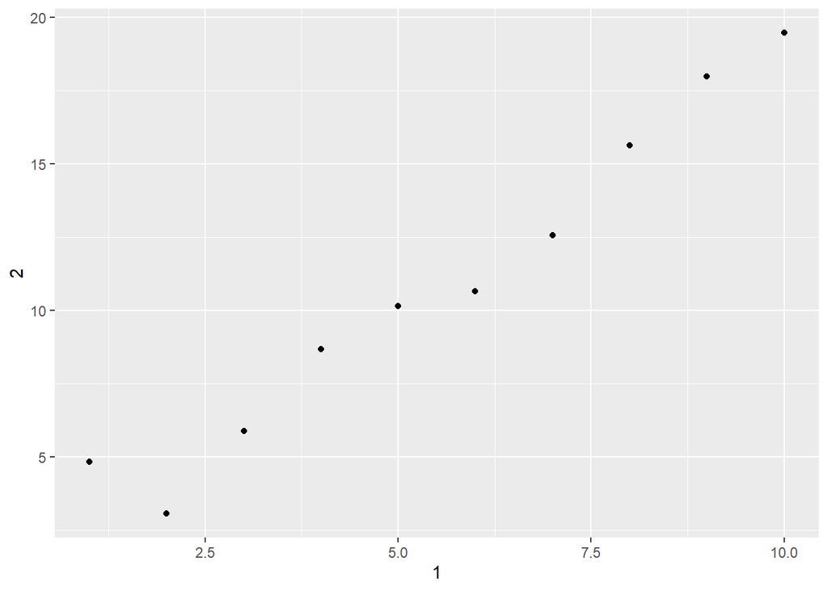

```r
ggplot() + geom_point(data = annoying, mapping = aes(x = `1`, y = `2`))
```

```r
annoying$`3` <- annoying$`2` / annoying$`1`
annoying
```

```
## # A tibble: 10 × 3
##      `1`   `2`   `3`
##    <int> <dbl> <dbl>
##  1     1  4.82  4.82
##  2     2  3.05  1.53
##  3     3  5.88  1.96
##  4     4  8.67  2.17
##  5     5 10.1   2.03
##  6     6 10.6   1.77
##  7     7 12.6   1.79
##  8     8 15.6   1.95
##  9     9 18.0   2.00
## 10    10 19.5   1.95
```

```r
annoying %>% rename(one = `1`, two = `2`, three = `3`)
```

```
## # A tibble: 10 × 3
##      one   two three
##    <int> <dbl> <dbl>
##  1     1  4.82  4.82
##  2     2  3.05  1.53
##  3     3  5.88  1.96
##  4     4  8.67  2.17
##  5     5 10.1   2.03
##  6     6 10.6   1.77
##  7     7 12.6   1.79
##  8     8 15.6   1.95
##  9     9 18.0   2.00
## 10    10 19.5   1.95
```

# Textbook 11.2.2

## Problem 5

```r
read_csv("a,b\n1,2,3\n4,5,6")
```

```
## # A tibble: 2 × 2
##       a     b
##   <dbl> <dbl>
## 1     1    23
## 2     4    56
```

a, b 두개의 열만 생성되어 첫 행의 2,3이 각각 저장되는 것이 아니라 23으로 저장됩니다.

```r
read_csv("a,b,c\n1,2\n1,2,3,4")
```

```
## # A tibble: 2 × 3
##       a     b     c
##   <dbl> <dbl> <dbl>
## 1     1     2    NA
## 2     1     2    34
```

열은 3개이지만 첫 행의 값은 2개이므로 마지막은 na가 됩니다. 그리고 2번째 행은 값이 4개이므로 마지막 2개는 합쳐져 34가 됩니다.

```r
read_csv("a,b\n\"1")
```

```
## # A tibble: 0 × 2
## # … with 2 variables: a <chr>, b <chr>
```

tibble이 출력되지 않습니다.

```r
read_csv("a,b\n1,2\na,b")
```

```
## # A tibble: 2 × 2
##   a     b
##   <chr> <chr>
## 1 1     2
## 2 a     b
```

두번째 행이 문자열이므로 첫번째 행도 문자열로 저장되었습니다.

```r
read_csv("a;b\n1;3")
```

```
## # A tibble: 1 × 1
##   `a;b`
##   <chr>
## 1 1;3
```

`read_csv()`는 ,로 구분하므로 ;는 문자열로 처리되었습니다.

# Textbook 11.3.5

## Problem 4

`read_csv()`는 쉼표로 구분됩니다. `read_csv2()`세미콜론으로 구분됩니다. ## Problem 7

```r
d1 <- "January 1, 2010"
d2 <- "2015-Mar-07"
d3 <- "06-Jun-2017"
d4 <- c("August 19 (2015)", "July 1 (2015)")
d5 <- "12/30/14" # Dec 30, 2014
t1 <- "1705"
t2 <- "11:15:10.12 PM"
```

```r
parse_date(d1, "%B %d, %Y")
```

```
## [1] "2010-01-01"
```

```r
parse_date(d2, "%Y-%b- %d")
```

```
## [1] "2015-03-07"
```

```r
parse_date(d3, "%d-%b-%Y")
```

```
## [1] "2017-06-06"
```

```r
parse_date(d4, "%B %d (%Y)")
```

```
## [1] "2015-08-19" "2015-07-01"
```

```r
parse_date(d5, "%m/%d/%y")
```

```
## [1] "2014-12-30"
```

```r
parse_time(t1, "%H%M")
```

```
## 17:05:00
```

```r
parse_time(t2, "%I:%M:%OS %p")
```

```
## 23:15:10.12
```

# Extra Questions

## Q1

```r
options("getSymbols.warning4.0"=FALSE) # to suppress warnings
skt <- getSymbols("017670.KS", auto.assign=FALSE)  # KOSPI tick number is 017670
head(skt)
```

```
##            017670.KS.Open 017670.KS.High 017670.KS.Low 017670.KS.Close
## 2007-01-02       72115.15       73432.32      72115.15        73103.02
## 2007-01-03       73103.02       73432.32      71785.85        71785.85
## 2007-01-04       71621.21       72773.73      70797.98        72609.09
## 2007-01-05       71785.85       73267.67      71127.27        73267.67
## 2007-01-08       73432.32       74255.55      72609.09        73432.32
## 2007-01-09       73103.02       73267.67      71785.85        72115.15
##            017670.KS.Volume 017670.KS.Adjusted
## 2007-01-02           296957           35835.40
## 2007-01-03           321485           35189.73
## 2007-01-04           432590           35593.27
## 2007-01-05           451285           35916.12
## 2007-01-08           534539           35996.84
## 2007-01-09           418402           35351.15
```

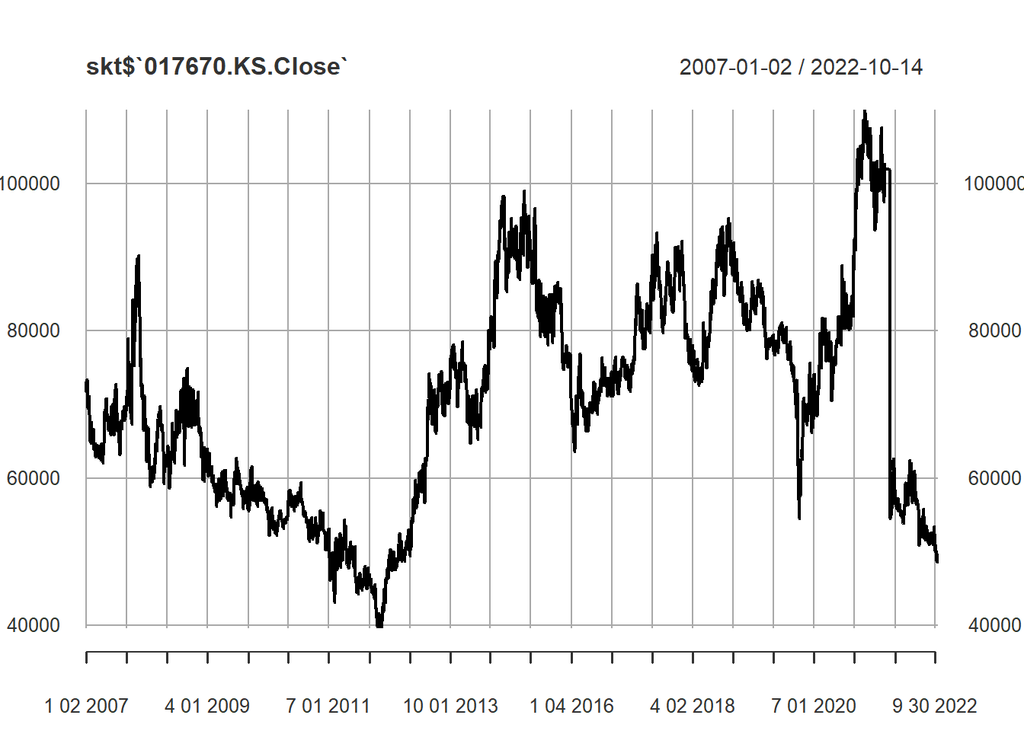

```r
plot(skt$`017670.KS.Close`)
```

### a

```r
df_skt <- data.frame(skt)
df_skt <- rownames_to_column(df_skt, var = "date")
tb_skt <- as_tibble(skt)
```

```r
tb_skt$date <- base::as.Date(df_skt$date, '%Y-%m-%d')
tb_skt
```

```
## # A tibble: 3,907 × 7
##    `017670.KS.Open` `017670.KS.High` 017670…¹ 01767…² 01767…³ 01767…⁴ date
##               <dbl>            <dbl>    <dbl>   <dbl>   <dbl>   <dbl> <date>
##  1           72115.           73432.   72115.  73103.  296957  35835. 2007-01-02
##  2           73103.           73432.   71786.  71786.  321485  35190. 2007-01-03
##  3           71621.           72774.   70798.  72609.  432590  35593. 2007-01-04
##  4           71786.           73268.   71127.  73268.  451285  35916. 2007-01-05
##  5           73432.           74256.   72609.  73432.  534539  35997. 2007-01-08
##  6           73103.           73268.   71786.  72115.  418402  35351. 2007-01-09
##  7           71292.           71457.   69316.  69481.  696838  34060. 2007-01-10
##  8           69481.           70798.   69481.  70469.  446912  34544. 2007-01-11
##  9           71127.           71127.   69810.  69975.  258906  34302. 2007-01-12
## 10           70633.           70633.   68658.  69481.  803193  34060. 2007-01-15
## # … with 3,897 more rows, and abbreviated variable names ¹`017670.KS.Low`,
## #   ²`017670.KS.Close`, ³`017670.KS.Volume`, ⁴`017670.KS.Adjusted`
```

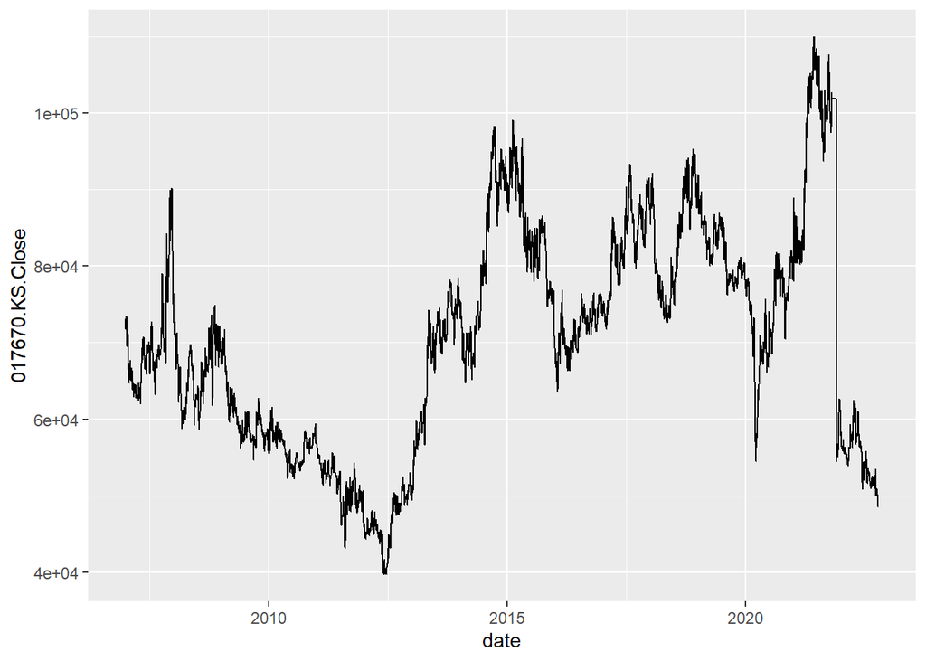

```r
ggplot(data = tb_skt, mapping = aes(x = date, y = `017670.KS.Close`)) + geom_line()
```

### b

```r
getFX('KRW/USD', Sys.Date()-180, Sys.Date())
```

```
## [1] "KRW/USD"
```

```r
getFX('KRW/JPY', Sys.Date()-180, Sys.Date())
```

```
## [1] "KRW/JPY"
```

```r
USD <- data.frame(KRWUSD)
JPY <- data.frame(KRWJPY)
```

```r
USD <- rownames_to_column(USD, var = "date")
USD$date <- base::as.Date(USD$date, '%Y-%m-%d')
JPY <- rownames_to_column(JPY, var = "date")
JPY$date <- base::as.Date(JPY$date, '%Y-%m-%d')
```

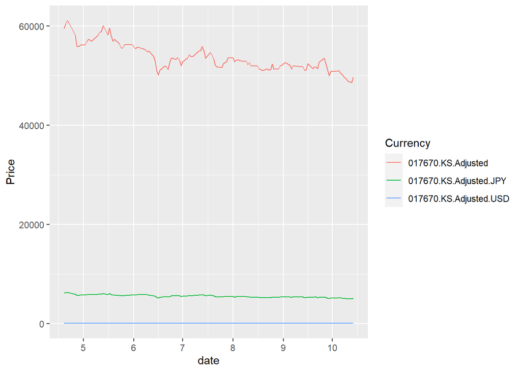

```r
inner_join(tb_skt, USD, by = "date") %>% inner_join(JPY, by="date") %>% select(`017670.KS.Adjusted`, date, `KRW.USD`, `KRW.JPY`) %>% mutate(`017670.KS.Adjusted.USD` = `017670.KS.Adjusted` * `KRW.USD`, `017670.KS.Adjusted.JPY` = `017670.KS.Adjusted` * `KRW.JPY`) %>% gather(`017670.KS.Adjusted`, `017670.KS.Adjusted.USD`, `017670.KS.Adjusted.JPY`, key = "Currency", value = "Price") %>% ggplot(mapping = aes(x = date, y= Price, color = Currency)) + geom_line()
```

1원당 달리가치와 엔화가치를 각각 USD와 JPY에 data.frame으로 저장한 후, rowname을 date라는 column에 추가하였습니다. 그 후에 데이터타입을 date로 변환하였습니다. 그리고 tb_skt와 USD, JPY의 교집합을 구하여 같은 날짜를 가진 데이터를 만들었습니다. 환율과 ADJUSTED된 금액을 곱하여 JPY와 USD 통화량으로 변환하였습니다. LONGFORM으로 변환하여 각 값에 어떤 나라의 가격인지를 추가하였고 이를 선그래프로 그렸습니다.

## 2

### a

```r
population <- read_csv("population.csv")
```

```
## ────────────────────────────────────────────────────────
## 2015...5, 2015...6, 2015...7,...
```

```r
seoul2020<-population[3:27, c(1:2,43:50)]
seoul2020
```

```
## # A tibble: 25 × 10
##    행정구역별(…¹  연령별 2020.…² 2020.…³ 2020.…⁴ 2020.…⁵ 2020.…⁶ 2020.…⁷ 2020.…⁸
##    <chr>          <chr>  <chr>   <chr>   <chr>   <chr>   <chr>   <chr>   <chr>
##  1 　　　종로구   합계   151,291 73,062  78,229  93.4    139,718 67,919  71,799
##  2 　　　중구     합계   128,744 62,147  66,597  93.3    117,252 56,725  60,527
##  3 　　　용산구   합계   225,882 109,162 116,720 93.5    208,602 99,866  108,736
##  4 　　　성동구   합계   291,918 142,128 149,790 94.9    281,266 137,301 143,965
##  5 　　　광진구   합계   353,967 169,925 184,042 92.3    333,985 161,130 172,855
##  6 　　　동대문구 합계   351,057 171,484 179,573 95.5    331,833 163,507 168,326
##  7 　　　중랑구   합계   385,663 189,537 196,126 96.6    378,258 186,593 191,665
##  8 　　　성북구   합계   438,833 209,682 229,151 91.5    425,295 204,207 221,088
##  9 　　　강북구   합계   299,535 144,779 154,756 93.6    294,351 142,837 151,514
## 10 　　　도봉구   합계   315,979 153,080 162,899 94.0    312,852 151,906 160,946
## # … with 15 more rows, 1 more variable: `2020...50` <chr>, and abbreviated
## #   variable names ¹`행정구역별(읍면동)`, ²`2020...43`, ³`2020...44`,
## #   ⁴`2020...45`, ⁵`2020...46`, ⁶`2020...47`, ⁷`2020...48`, ⁸`2020...49`
```

```r
df_seoul2020 <- data.frame(seoul2020)
```

### b

```r
seoul2020tidy <- column_to_rownames(seoul2020, var = "행정구역별(읍면동)")
colnames(seoul2020tidy)[2:9] <- unlist(population[1,3:10])
```

seoul2020이 갖고 있는 문제점은 두가지입니다. -첫열이 행이름이 되어야한다. -열이름이 나타내는 정보가 불분명하다.

그래인서 `column_to_rownames()`와 `colnames()`을 사용했습니다.

### c

```r
seoul2020tidy$`총인구(명)` <- parse_number(seoul2020tidy$`총인구(명)`)
seoul2020tidy$`총인구_남자(명)` <- parse_number(seoul2020tidy$`총인구_남자(명)`)
seoul2020tidy$`총인구_여자(명)` <- parse_number(seoul2020tidy$`총인구_여자(명)`)
seoul2020tidy$`총인구_성비` <- parse_double(seoul2020tidy$`총인구_성비`)
seoul2020tidy$`내국인(명)` <- parse_number(seoul2020tidy$`내국인(명)`)
seoul2020tidy$`내국인_남자(명)` <- parse_number(seoul2020tidy$`내국인_남자(명)`)
seoul2020tidy$`내국인_여자(명)` <- parse_number(seoul2020tidy$`내국인_여자(명)`)
seoul2020tidy$`내국인_성비` <- parse_double(seoul2020tidy$`내국인_성비`)
seoul2020tidy
```

```
##                연령별 총인구(명) 총인구_남자(명) 총인구_여자(명) 총인구_성비
## 　　　종로구     합계     151291           73062           78229        93.4
## 　　　중구       합계     128744           62147           66597        93.3
## 　　　용산구     합계     225882          109162          116720        93.5
## 　　　성동구     합계     291918          142128          149790        94.9
## 　　　광진구     합계     353967          169925          184042        92.3
## 　　　동대문구   합계     351057          171484          179573        95.5
## 　　　중랑구     합계     385663          189537          196126        96.6
## 　　　성북구     합계     438833          209682          229151        91.5
## 　　　강북구     합계     299535          144779          154756        93.6
## 　　　도봉구     합계     315979          153080          162899        94.0
## 　　　노원구     합계     511982          246317          265665        92.7
## 　　　은평구     합계     463102          221828          241274        91.9
## 　　　서대문구   합계     317209          148696          168513        88.2
## 　　　마포구     합계     365612          171161          194451        88.0
## 　　　양천구     합계     439068          214978          224090        95.9
## 　　　강서구     합계     564854          271779          293075        92.7
## 　　　구로구     합계     435442          216855          218587        99.2
## 　　　금천구     합계     249419          126490          122929       102.9
## 　　　영등포구   합계     403619          200678          202941        98.9
## 　　　동작구     합계     392772          189611          203161        93.3
## 　　　관악구     합계     502641          250850          251791        99.6
## 　　　서초구     합계     401749          192081          209668        91.6
## 　　　강남구     합계     508135          243322          264813        91.9
## 　　　송파구     합계     643288          309802          333486        92.9
## 　　　강동구     합계     444434          218299          226135        96.5
##                내국인(명) 내국인_남자(명) 내국인_여자(명) 내국인_성비
## 　　　종로구       139718           67919           71799        94.6
## 　　　중구         117252           56725           60527        93.7
## 　　　용산구       208602           99866          108736        91.8
## 　　　성동구       281266          137301          143965        95.4
## 　　　광진구       333985          161130          172855        93.2
## 　　　동대문구     331833          163507          168326        97.1
## 　　　중랑구       378258          186593          191665        97.4
## 　　　성북구       425295          204207          221088        92.4
## 　　　강북구       294351          142837          151514        94.3
## 　　　도봉구       312852          151906          160946        94.4
## 　　　노원구       506237          243759          262478        92.9
## 　　　은평구       456902          219268          237634        92.3
## 　　　서대문구     302902          143329          159573        89.8
## 　　　마포구       352890          165953          186937        88.8
## 　　　양천구       433221          212412          220809        96.2
## 　　　강서구       555952          267919          288033        93.0
## 　　　구로구       389832          192124          197708        97.2
## 　　　금천구       222303          112014          110289       101.6
## 　　　영등포구     356649          175746          180903        97.1
## 　　　동작구       376840          182415          194425        93.8
## 　　　관악구       478545          239878          238667       100.5
## 　　　서초구       394326          188488          205838        91.6
## 　　　강남구       498857          238710          260147        91.8
## 　　　송파구       633026          305040          327986        93.0
## 　　　강동구       437847          215297          222550        96.7
```

### d

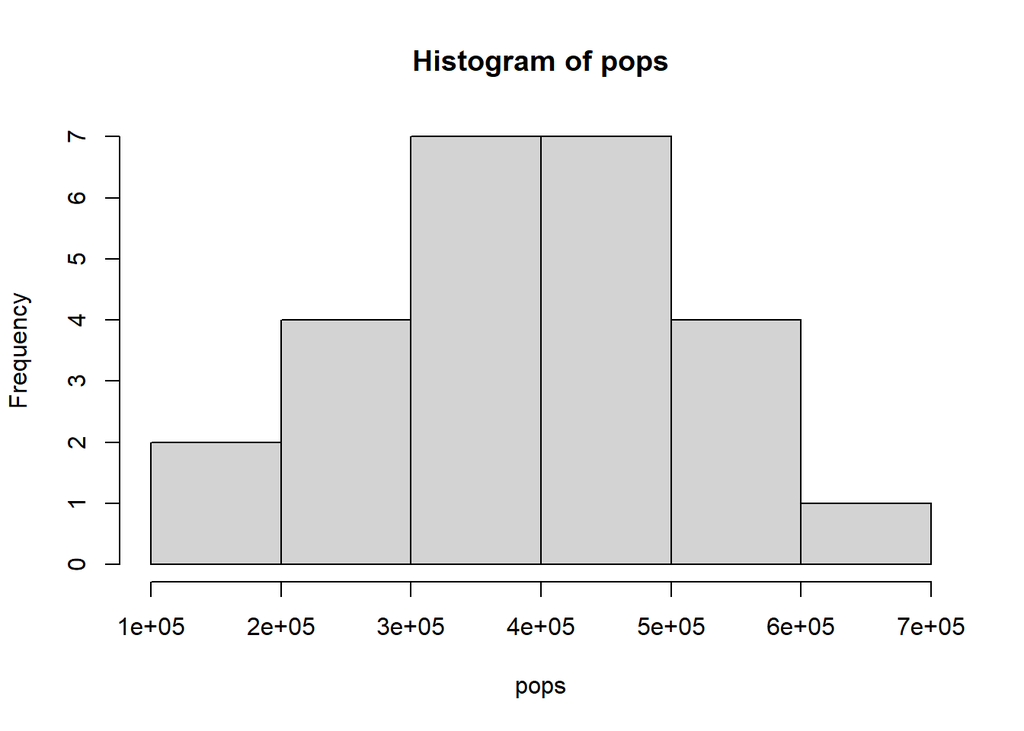

```r
pops <- unlist(seoul2020tidy[, 2])
hist(pops)
```

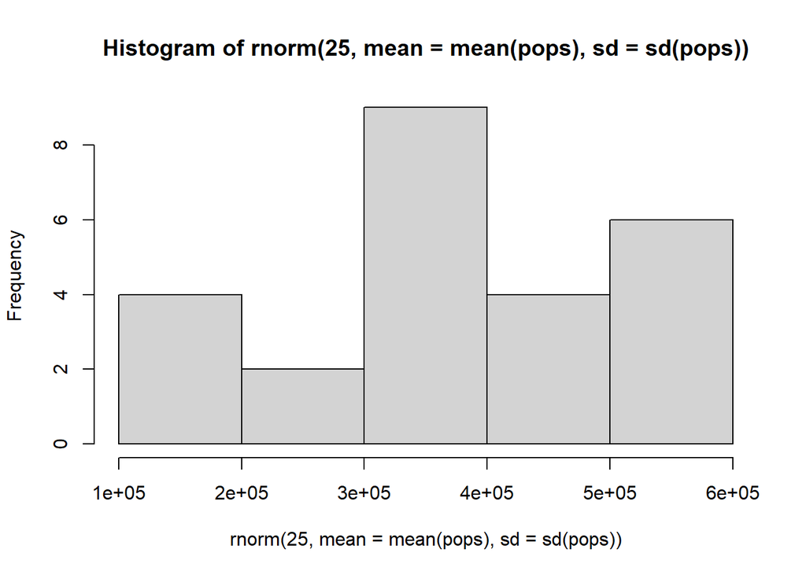

```r
hist(rnorm(25, mean = mean(pops), sd = sd(pops)))
```

히스토그램이 유사한 모양을 그리지 않는다.

### e

```r
mean(pops)
```

```
## [1] 383447.8
```

```r
mean(sample(pops, 10, replace = TRUE))
```

```
## [1] 413983.1
```

```r
mean(sample(pops, 10, replace = TRUE))
```

```
## [1] 395809.1
```

sample vector의 평균은 pops의 평균과 다르다. 또한, sample vector 끼리의 평균도 큰 차이를 보인다. 그 이유는 관측단위별 총인구수간에 차이가 있기 때문에, 어떤 값이 sampling 되느냐에 따라 평균이 달라지기 때문이다. ### f

```r
mean(replicate(100, mean(sample(pops, 10, replace = TRUE))))
```

```
## [1] 387228.7
```

```r
mean(replicate(1000, mean(sample(pops, 10, replace = TRUE))))
```

```
## [1] 381945.2
```

```r
mean(replicate(10000, mean(sample(pops, 10, replace = TRUE))))
```

```
## [1] 383369.6
```

표본평균의 평균을 구하는 과정입니다. 표본평균의 수가 늘어날수록 모집단의 평균과 비슷합니다.

### g

```r
mean(sample(pops, 10, replace = TRUE))
```

```
## [1] 338699.1
```

```r
mean(sample(pops, 25, replace = TRUE))
```

```
## [1] 403053.3
```

```r
mean(sample(pops, 100, replace = TRUE))
```

```
## [1] 371547.9
```

표본의 수가 늘어날 수록 꼭 모평균과 가까워진다고 말하기는 어렵습니다. 하지만 여러번 실행했을 때 표본평균이 변화하는 범위가 모평균 근처에서 표본이 늘어날수록 가장 좁았습니다.

### h

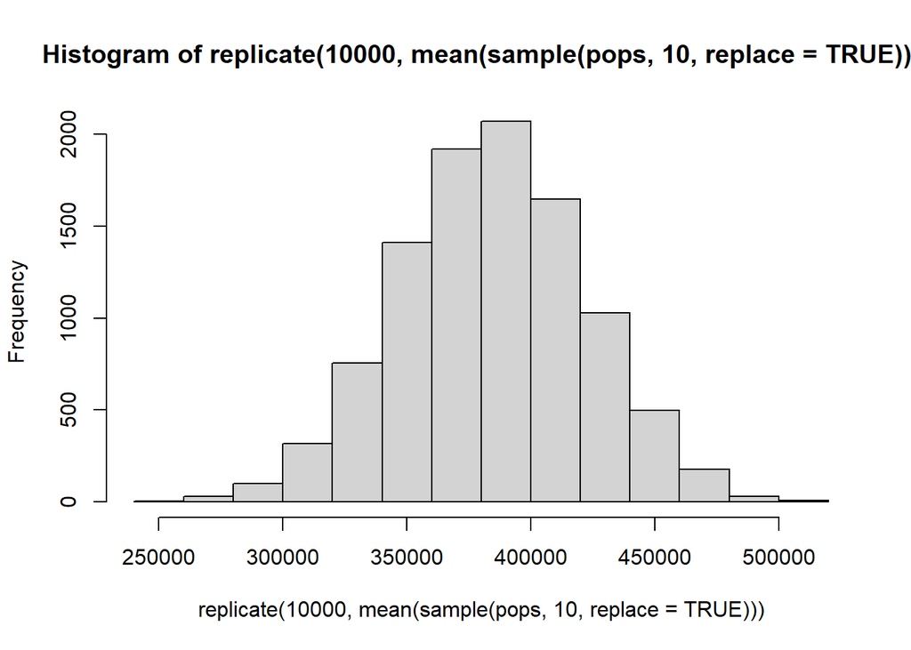

```r
hist(replicate(10000, mean(sample(pops, 10, replace = TRUE))))
```

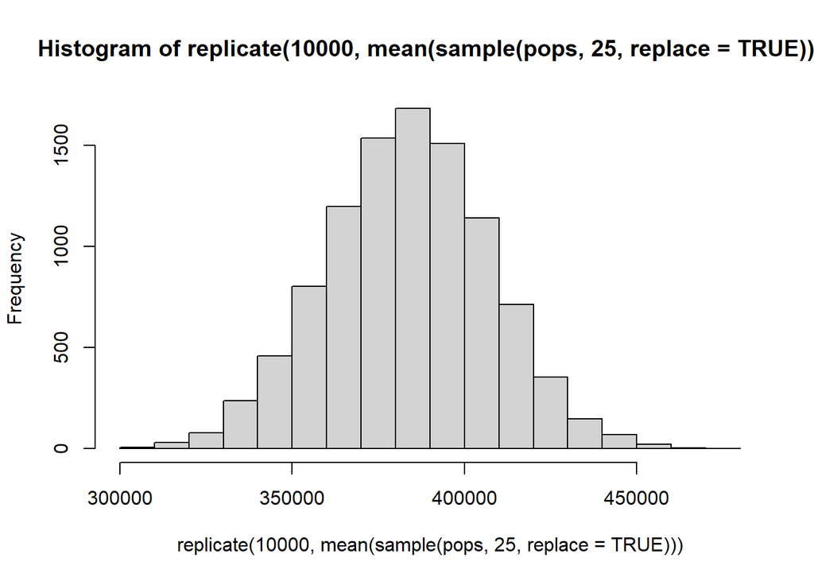

```r
hist(replicate(10000, mean(sample(pops, 25, replace = TRUE))))
```

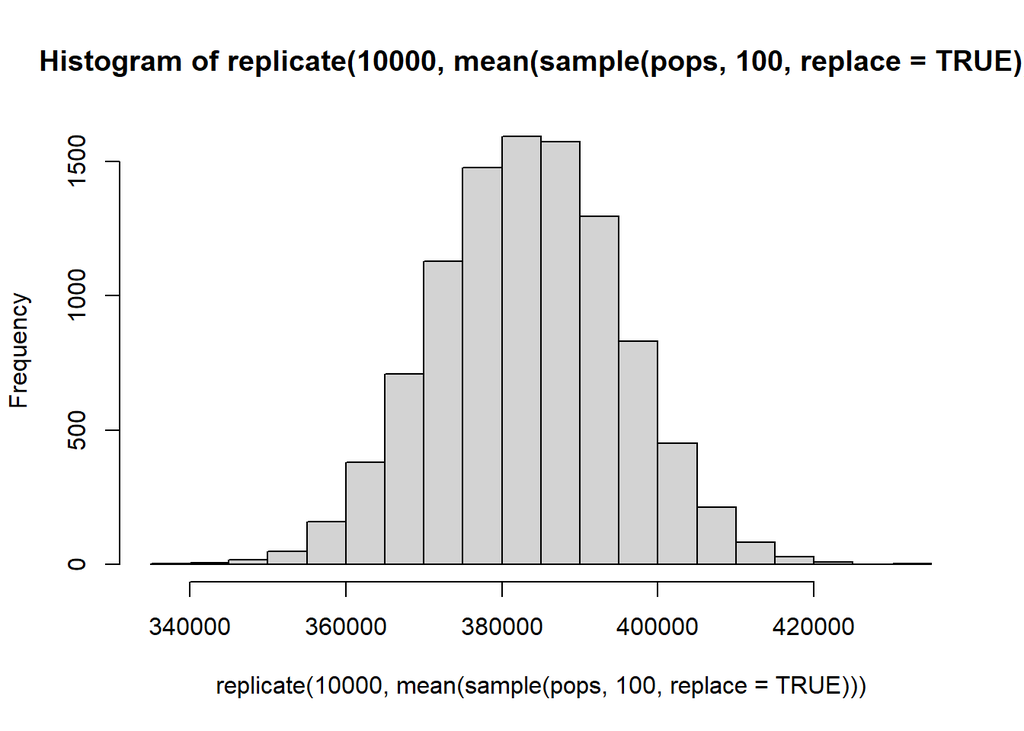

```r
hist(replicate(10000, mean(sample(pops, 100, replace = TRUE))))
```

모집단과 유사한 분포를 보입니다. 또한, 표본의 크기가 클 수록 정규분포와 비슷합니다. 이를 중심극한정리라고 합니다.

### i

```r
quantile(replicate(1000, mean(sample(pops, 10, replace = TRUE))))
```

```
##       0%      25%      50%      75%     100%
## 253339.5 357687.5 383080.8 406838.8 522914.7
```

서울 인구 데이터에서 10의 표본을 무작위 추출하여 평균을 구하는 일을 1000번 반복했을 때의 분위수는 위와 같습니다. 1000번 반복했을 때의 최솟값보다도 평균이 낮으니 평균이 204885인 10개의 데이터 셋은 서울시 인구로부터 얻어진 데이터가 아니라고 생각합니다.